title: “Machine Learning Assignment” author: “Tong-Fatt Ho” date: “16 September 2016” output: html_document

## 1. Synopsis

The goal of this project is to use data collected from devices such as Jawbone Up, Nike Fuelband and Fitbit, worn by 6 participants on their belts, forearm, arm and dumbell, to find out how well they did certain instructed tasks based on specific instructions. These tasks were designed to compare the data collected on tasks that were done correctly and incorretly in 5 dfferent ways. Machine learning algorithm, namely Random Forest, is used to analyze and predict. Differences in accuracies of prediction under different approaches will be compared and analyzed: a) no pre-process b) pre-process with scaling and centreing c) PCA with scaling and centreing

## 2. Load Libraries

```r
library(ISLR)
library(ggplot2)
library(lattice)
library(kernlab)
library(caret)
library(rattle)
library(rpart)
library(parallel)
library(doParallel)
```

## 3. Data Preparation

### 3.1 Load Data

```r
pmltrain <- read.csv("pml-training.csv")
pmltest <- read.csv("pml-testing.csv")
```

### 3.2 Remove blanks, NA and non-related variables

```r
trash_train = sapply(1:dim(pmltrain)[2],function(x) any(is.na(pmltrain[,x])|pmltrain[,x]==""))
trash_test = sapply(1:dim(pmltest)[2],function(x) any(is.na(pmltest[,x])|pmltest[,x]==""))

cleaned_pmltrain <- pmltrain[,!trash_train]
cleaned_pmltest <- pmltest[,!trash_test]

pmltrainP <- cleaned_pmltrain[,grepl("belt|dumbbell|arm|classe", names(cleaned_pmltrain))]
pmltestP <- cleaned_pmltest[,grepl("belt|dumbbell|arm|classe", names(cleaned_pmltest))]

dim(pmltrainP);dim(pmltestP)
```

```
## [1] 19622    53
```

```
## [1] 20 52
```

```
  The training and testing data sets have different number of variables. Hence, need to know what the differences are between the 2 datasets in terms of variables.
```

```r
bug <- grep("TRUE", names(pmltrain)!=names(pmltest))
names(pmltrain[bug])
```

```
## [1] "classe"
```

```r
names(pmltest[bug])
```

```
## [1] "problem_id"
```

```
  The difference is only in column 53, rest of columns have the same variables between the respective columns between the two datasets. Training data contains 'classe' data whereas testing data contains 'problem ID'in column 53.
```

## 4. Further Partitioning Datasets into Training and Validation

```r
seed <- as.numeric(as.Date("2017-09-16"))
set.seed(seed)
InTrain <- createDataPartition(pmltrainP$classe, p = 0.6)[[1]]
train <- pmltrainP[InTrain, ]
valid8 <- pmltrainP[-InTrain,]
```

## 5.Perform Exploratory Analysis on Data

### 5.1 Identify highly correlated predictors

```r
M <- abs(cor(train[,-53]))
diag(M)<- 0
which(M > 0.8, arr.ind = TRUE)
```

```
##                  row col
## yaw_belt           3   1
## total_accel_belt   4   1
## accel_belt_y       9   1
## accel_belt_z      10   1
## accel_belt_x       8   2
## magnet_belt_x     11   2
## roll_belt          1   3
## roll_belt          1   4
## accel_belt_y       9   4
## accel_belt_z      10   4
## pitch_belt         2   8
## magnet_belt_x     11   8
## roll_belt          1   9
## total_accel_belt   4   9
## accel_belt_z      10   9
## roll_belt          1  10
## total_accel_belt   4  10
## accel_belt_y       9  10
## pitch_belt         2  11
## accel_belt_x       8  11
## gyros_arm_y       19  18
## gyros_arm_x       18  19
## magnet_arm_x      24  21
## accel_arm_x       21  24
## magnet_arm_z      26  25
## magnet_arm_y      25  26
## accel_dumbbell_x  34  28
## accel_dumbbell_z  36  29
## pitch_dumbbell    28  34
## yaw_dumbbell      29  36
```

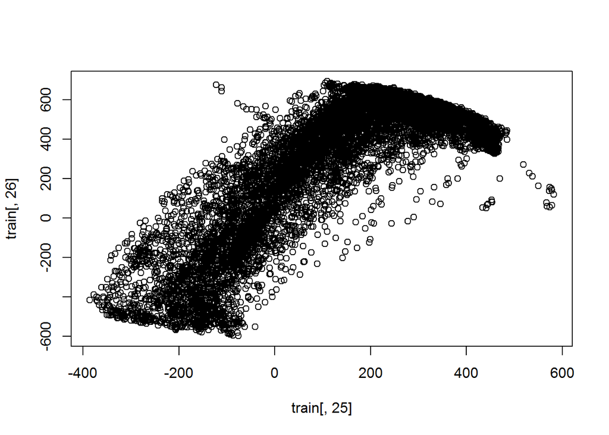

```r
plot(train[,25],train[,26])
```

- The plot above shows high correlation betwwen column 25 and 26, among others. It suggest that using PCA predictors reduce the number of predictors may help to reduce noise by averaging.
- However, the plot below does not show clear separation of the performance classification in classe. It does not look like PCA will make models fit better. The expected out of sample error may not be mitigated by applying PCA. be This will be explored below.

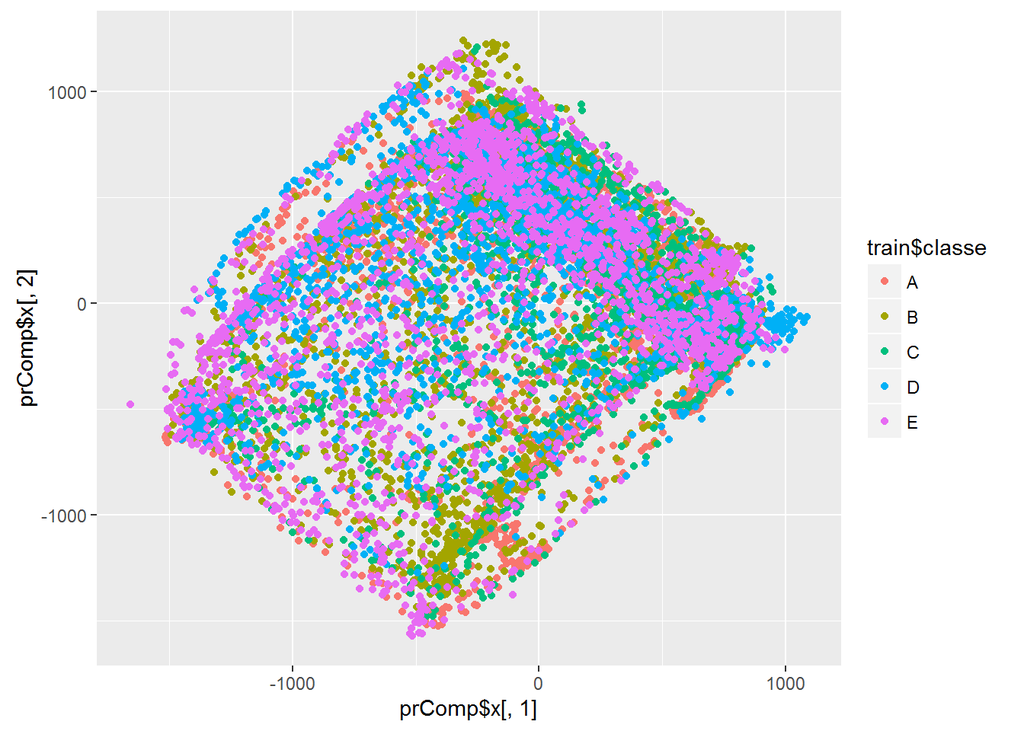

```r
prComp <- prcomp(train[,-53])
qplot(prComp$x[,1],prComp$x[,2],color = train$classe)
```

### 5.2 Perform PCA pre-processes

```r
set.seed(seed)
preProc <- preProcess(train, method = "pca")
preProc
```

```
## Created from 11776 samples and 53 variables
##
## Pre-processing:
##   - centered (52)
##   - ignored (1)
##   - principal component signal extraction (52)
##   - scaled (52)
##
## PCA needed 26 components to capture 95 percent of the variance
```

- apply pre-process on train and validate data sets for model fit in following sections

```r
trainPC <- predict(preProc, train[,-53])
valid8PC <- predict(preProc, valid8[,-53])
```

- Model Fitting

```r
team <- makeCluster(detectCores() - 1)
registerDoParallel(team)
tuner <- trainControl(method="cv", number=5, classProbs = TRUE, allowParallel=TRUE, verboseIter=FALSE)

system.time(modelfitpca <- train(x = trainPC, y = train$classe, method = "rf", trControl = tuner))
```

```
##    user  system elapsed
##   24.42    0.33  237.17
```

```r
modelfitpca$finalModel
```

```
##
## Call:
##  randomForest(x = x, y = y, mtry = param$mtry)
##                Type of random forest: classification
##                      Number of trees: 500
## No. of variables tried at each split: 2
##
##         OOB estimate of  error rate: 3.2%
## Confusion matrix:
##      A    B    C    D    E class.error
## A 3319    9    8    6    6 0.008661888
## B   59 2167   42    3    8 0.049144362
## C    7   44 1975   25    3 0.038461538
## D    5    1   98 1822    4 0.055958549
## E    4   11   19   15 2116 0.022632794
```

- Test model using validation dataset

```r
predicthat <- predict(modelfitpca, valid8PC)
confusionMatrix(predicthat, valid8[,53])
```

```
## Confusion Matrix and Statistics
##
##           Reference
## Prediction    A    B    C    D    E
##          A 2206   21    0    4    3
##          B   17 1467   40    0    7
##          C    5   25 1315   56   13
##          D    2    3    9 1222   11
##          E    2    2    4    4 1408
##
## Overall Statistics
##
##                Accuracy : 0.9709
##                  95% CI : (0.967, 0.9745)
##     No Information Rate : 0.2845
##     P-Value [Acc > NIR] : < 2.2e-16
##
##                   Kappa : 0.9632
##  Mcnemar's Test P-Value : 1.054e-08
##
## Statistics by Class:
##
##                      Class: A Class: B Class: C Class: D Class: E
## Sensitivity            0.9884   0.9664   0.9613   0.9502   0.9764
## Specificity            0.9950   0.9899   0.9847   0.9962   0.9981
## Pos Pred Value         0.9875   0.9582   0.9300   0.9800   0.9915
## Neg Pred Value         0.9954   0.9919   0.9918   0.9903   0.9947
## Prevalence             0.2845   0.1935   0.1744   0.1639   0.1838
## Detection Rate         0.2812   0.1870   0.1676   0.1557   0.1795
## Detection Prevalence   0.2847   0.1951   0.1802   0.1589   0.1810
## Balanced Accuracy      0.9917   0.9781   0.9730   0.9732   0.9873
```

- Perform C&S Pre-processing

```r
set.seed(seed)
preProc <- preProcess(train[,-53])
preProc
```

```
## Created from 11776 samples and 52 variables
##
## Pre-processing:
##   - centered (52)
##   - ignored (0)
##   - scaled (52)
```

### 5.3 Apply C&S pre-processing on predictors and model fitting

```r
trainPC <- predict(preProc, valid8[,-53])
valid8PC <- predict(preProc, valid8[,-53])
```

- Applying C&S predictors and model fitting

```r
trainPC <- predict(preProc, train[,-53])
system.time(modelfitcns <- train(y = train[,53], x = trainPC, method = "rf", trControl = tuner))
```

```
##    user  system elapsed
##   33.30    0.19  446.85
```

```r
modelfitcns$finalModel
```

```
##
## Call:
##  randomForest(x = x, y = y, mtry = param$mtry)
##                Type of random forest: classification
##                      Number of trees: 500
## No. of variables tried at each split: 2
##
##         OOB estimate of  error rate: 0.94%
## Confusion matrix:
##      A    B    C    D    E  class.error
## A 3345    2    0    0    1 0.0008960573
## B   20 2246   13    0    0 0.0144800351
## C    1   21 2030    2    0 0.0116845180
## D    0    0   43 1886    1 0.0227979275
## E    0    0    3    4 2158 0.0032332564
```

- Test model using validation dataset

```r
predicthat <- predict(modelfitcns, valid8PC)
confusionMatrix(predicthat, valid8[,53])
```

```
## Confusion Matrix and Statistics
##
##           Reference
## Prediction    A    B    C    D    E
##          A 2226    2    0    0    0
##          B    6 1515   18    0    0
##          C    0    1 1349   23    1
##          D    0    0    1 1262    3
##          E    0    0    0    1 1438
##
## Overall Statistics
##
##                Accuracy : 0.9929
##                  95% CI : (0.9907, 0.9946)
##     No Information Rate : 0.2845
##     P-Value [Acc > NIR] : < 2.2e-16
##
##                   Kappa : 0.991
##  Mcnemar's Test P-Value : NA
##
## Statistics by Class:
##
##                      Class: A Class: B Class: C Class: D Class: E
## Sensitivity            0.9973   0.9980   0.9861   0.9813   0.9972
## Specificity            0.9996   0.9962   0.9961   0.9994   0.9998
## Pos Pred Value         0.9991   0.9844   0.9818   0.9968   0.9993
## Neg Pred Value         0.9989   0.9995   0.9971   0.9964   0.9994
## Prevalence             0.2845   0.1935   0.1744   0.1639   0.1838
## Detection Rate         0.2837   0.1931   0.1719   0.1608   0.1833
## Detection Prevalence   0.2840   0.1962   0.1751   0.1614   0.1834
## Balanced Accuracy      0.9985   0.9971   0.9911   0.9904   0.9985
```

### 5.4 Model fitting using unprocessed predictors

```r
set.seed(seed)
system.time(modelfits <- train(classe ~ ., method = "rf", data = train, trControl = tuner))
```

```
##    user  system elapsed
##   37.40    0.23  398.80
```

```r
modelfits$finalModel
```

```
##
## Call:
##  randomForest(x = x, y = y, mtry = param$mtry)
##                Type of random forest: classification
##                      Number of trees: 500
## No. of variables tried at each split: 2
##
##         OOB estimate of  error rate: 0.86%
## Confusion matrix:
##      A    B    C    D    E  class.error
## A 3347    1    0    0    0 0.0002986858
## B   16 2254    9    0    0 0.0109697236
## C    0   20 2032    2    0 0.0107108082
## D    0    0   45 1884    1 0.0238341969
## E    0    0    3    4 2158 0.0032332564
```

```r
stopCluster(team)
```

- Test model using validate data set

```r
predicthat <- predict(modelfits, valid8[,-53])
confusionMatrix(predicthat, valid8[,53])
```

```
## Confusion Matrix and Statistics
##
##           Reference
## Prediction    A    B    C    D    E
##          A 2226    3    0    0    0
##          B    6 1511   17    0    0
##          C    0    4 1349   24    0
##          D    0    0    2 1262    2
##          E    0    0    0    0 1440
##
## Overall Statistics
##
##                Accuracy : 0.9926
##                  95% CI : (0.9905, 0.9944)
##     No Information Rate : 0.2845
##     P-Value [Acc > NIR] : < 2.2e-16
##
##                   Kappa : 0.9906
##  Mcnemar's Test P-Value : NA
##
## Statistics by Class:
##
##                      Class: A Class: B Class: C Class: D Class: E
## Sensitivity            0.9973   0.9954   0.9861   0.9813   0.9986
## Specificity            0.9995   0.9964   0.9957   0.9994   1.0000
## Pos Pred Value         0.9987   0.9850   0.9797   0.9968   1.0000
## Neg Pred Value         0.9989   0.9989   0.9971   0.9964   0.9997
## Prevalence             0.2845   0.1935   0.1744   0.1639   0.1838
## Detection Rate         0.2837   0.1926   0.1719   0.1608   0.1835
## Detection Prevalence   0.2841   0.1955   0.1755   0.1614   0.1835
## Balanced Accuracy      0.9984   0.9959   0.9909   0.9904   0.9993
```

## 6. Conclusion

Based on the accuracy performance of the 3 approaches above, applying PCA on predictors in preprocessing does not seem to have helped to improve the accuracy. Even without applying any pre-processing, running model fit on the collected data directly achieved almost as good performance as predictors that have been pre-processed for standardizing to scale and centres. Therefore, the test data set will be applied directly for the next and final part of this assignment by running model fit without pre-processing the raw data.

## 7. Final test prediction using test dataset directly with no pre-processing

```r
predicthat <- predict(modelfits, pmltestP[,-53])
```

## 8. Predicted test data for submission

```r
pmltestsubmit <- cbind(predicthat,cleaned_pmltest[,!grepl("belt|dumbbell|arm|classe", names(cleaned_pmltest))])
pmltestsubmit
```

```
##    predicthat  X user_name raw_timestamp_part_1 raw_timestamp_part_2
## 1           B  1     pedro           1323095002               868349
## 2           A  2    jeremy           1322673067               778725
## 3           B  3    jeremy           1322673075               342967
## 4           A  4    adelmo           1322832789               560311
## 5           A  5    eurico           1322489635               814776
## 6           E  6    jeremy           1322673149               510661
## 7           D  7    jeremy           1322673128               766645
## 8           B  8    jeremy           1322673076                54671
## 9           A  9  carlitos           1323084240               916313
## 10          A 10   charles           1322837822               384285
## 11          B 11  carlitos           1323084277                36553
## 12          C 12    jeremy           1322673101               442731
## 13          B 13    eurico           1322489661               298656
## 14          A 14    jeremy           1322673043               178652
```

[output cut: 27 more lines]